# Tidying and Transforming Data: Airline Arrival Delays

Why Alaska beats AM West in every city but loses overall

Author

Aniss Sahraoui

Published

October 4, 2026

# 1 Overview

This assignment takes a small table of airline arrival records, tidies it in R, and compares the two airlines’ delay rates. The table counts **on time** and **delayed** arrivals for two airlines, ALASKA and AM WEST, across five west-coast cities.

The interesting part is the result. Comparing the airlines overall gives the opposite answer to comparing them city by city, and the reason is worth understanding before trusting any summary statistic.

# 2 The Data File

I recreated the table as a CSV in exactly the shape it was given, including the blank cells. The airline name appears only on its first row, and an empty row separates the two airlines.

```r
read_lines("https://raw.githubusercontent.com/AnissSahraoui/DATA607/main/Week5A/data/flights.csv") |>
  cat(sep = "\n")
```

```
,,Los Angeles,Phoenix,San Diego,San Francisco,Seattle
ALASKA,on time,497,221,212,503,1841
,delayed,62,12,20,102,305
,,,,,,
AM WEST,on time,694,4840,383,320,201
,delayed,117,415,65,129,61
```

The file is read from my GitHub repository, so this document runs on any machine.

```r
raw <- read_csv(
  "https://raw.githubusercontent.com/AnissSahraoui/DATA607/main/Week5A/data/flights.csv",
  show_col_types = FALSE,
  name_repair = "unique_quiet"
)

raw
```

| …1 | …2 | Los Angeles | Phoenix | San Diego | San Francisco | Seattle |
| --- | --- | --- | --- | --- | --- | --- |
| ALASKA | on time | 497 | 221 | 212 | 503 | 1841 |
| NA | delayed | 62 | 12 | 20 | 102 | 305 |
| NA | NA | NA | NA | NA | NA | NA |
| AM WEST | on time | 694 | 4840 | 383 | 320 | 201 |
| NA | delayed | 117 | 415 | 65 | 129 | 61 |

This is not tidy data. The first two columns have no names, the airline is missing on three rows, one row is entirely empty, and the five cities are spread across columns instead of being values of a single variable.

# 3 Tidying

## 3.1 Filling in the missing airline names

`fill()` carries the last non-missing value downward, which is exactly what the layout implies: the rows under ALASKA belong to ALASKA. The empty separator row is dropped by removing rows with no status.

```r
filled <- raw |>
  rename(airline = 1, status = 2) |>
  fill(airline) |>
  filter(!is.na(status))

filled
```

| airline | status | Los Angeles | Phoenix | San Diego | San Francisco | Seattle |
| --- | --- | --- | --- | --- | --- | --- |
| ALASKA | on time | 497 | 221 | 212 | 503 | 1841 |
| ALASKA | delayed | 62 | 12 | 20 | 102 | 305 |
| AM WEST | on time | 694 | 4840 | 383 | 320 | 201 |
| AM WEST | delayed | 117 | 415 | 65 | 129 | 61 |

## 3.2 Wide to long

`pivot_longer()` turns the five city columns into one `city` column, giving one row per airline, city and status.

```r
long <- filled |>
  pivot_longer(
    cols = -c(airline, status),
    names_to = "city",
    values_to = "flights"
  )

head(long, 6)
```

| airline | status | city | flights |
| --- | --- | --- | --- |
| ALASKA | on time | Los Angeles | 497 |
| ALASKA | on time | Phoenix | 221 |
| ALASKA | on time | San Diego | 212 |
| ALASKA | on time | San Francisco | 503 |
| ALASKA | on time | Seattle | 1841 |
| ALASKA | delayed | Los Angeles | 62 |

## 3.3 One row per airline and city

For comparing delays it is more useful to have on-time and delayed counts side by side, so I pivot the two statuses back into columns and calculate the totals and percentages.

```r
flights <- long |>
  mutate(status = str_replace(status, "on time", "on_time")) |>
  pivot_wider(names_from = status, values_from = flights) |>
  mutate(
    total      = on_time + delayed,
    delay_rate = delayed / total
  )

flights |> mutate(delay_rate = percent(delay_rate, 0.1))
```

| airline | city | on_time | delayed | total | delay_rate |
| --- | --- | --- | --- | --- | --- |
| ALASKA | Los Angeles | 497 | 62 | 559 | 11.1% |
| ALASKA | Phoenix | 221 | 12 | 233 | 5.2% |
| ALASKA | San Diego | 212 | 20 | 232 | 8.6% |
| ALASKA | San Francisco | 503 | 102 | 605 | 16.9% |
| ALASKA | Seattle | 1841 | 305 | 2146 | 14.2% |
| AM WEST | Los Angeles | 694 | 117 | 811 | 14.4% |
| AM WEST | Phoenix | 4840 | 415 | 5255 | 7.9% |
| AM WEST | San Diego | 383 | 65 | 448 | 14.5% |
| AM WEST | San Francisco | 320 | 129 | 449 | 28.7% |
| AM WEST | Seattle | 201 | 61 | 262 | 23.3% |

```r
tibble(
  rows               = nrow(flights),
  flights_in_table   = sum(flights$total),
  counts_match_input = sum(flights$total) == sum(raw[, 3:7], na.rm = TRUE),
  missing_values     = sum(is.na(flights))
)
```

| rows | flights_in_table | counts_match_input | missing_values |
| --- | --- | --- | --- |
| 10 | 11000 | TRUE | 0 |

Every count from the original table is accounted for, with nothing lost in the reshaping.

# 4 Comparing the Airlines Overall

```r
overall <- flights |>
  group_by(airline) |>
  summarise(
    on_time    = sum(on_time),
    delayed    = sum(delayed),
    total      = sum(total),
    .groups    = "drop"
  ) |>
  mutate(delay_rate = delayed / total)

overall |> mutate(delay_rate = percent(delay_rate, 0.1))
```

| airline | on_time | delayed | total | delay_rate |
| --- | --- | --- | --- | --- |
| ALASKA | 3274 | 501 | 3775 | 13.3% |
| AM WEST | 6438 | 787 | 7225 | 10.9% |

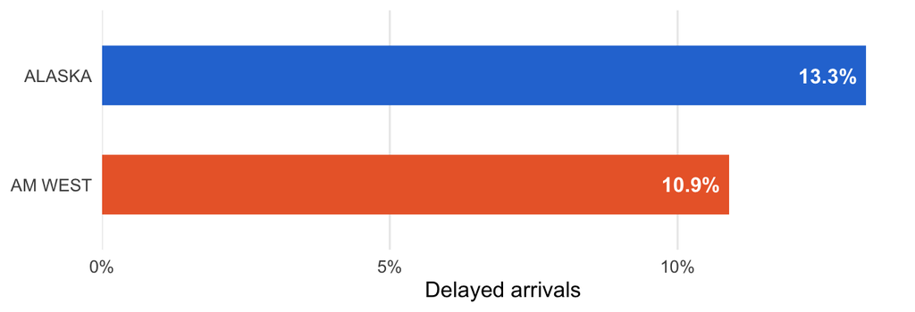

Figure 1: Overall percentage of arrivals that were delayed.

```r
ggplot(overall, aes(x = delay_rate, y = fct_rev(airline), fill = airline)) +
  geom_col(width = 0.55) +
  geom_text(aes(label = percent(delay_rate, 0.1)), hjust = 1.15,
            color = "white", fontface = "bold", size = 4) +
  scale_fill_manual(values = c(ALASKA = col_alaska, `AM WEST` = col_amwest), guide = "none") +
  scale_x_continuous(labels = percent_format(), expand = expansion(mult = c(0, 0.05))) +
  labs(x = "Delayed arrivals", y = NULL) +
  theme_report +
  theme(panel.grid.major.y = element_blank())
```

**Overall, AM WEST looks better.** 10.9% of its arrivals were delayed, against 13.3% for ALASKA, a gap of 2.4%. Percentages matter here: AM WEST recorded 7,225 arrivals against ALASKA’s 3,775, so comparing raw counts of delays would say more about airline size than about punctuality.

# 5 Comparing the Airlines City by City

```r
by_city <- flights |>
  select(airline, city, delay_rate) |>
  pivot_wider(names_from = airline, values_from = delay_rate) |>
  mutate(difference = `AM WEST` - ALASKA)

by_city |>
  mutate(across(where(is.numeric), ~ percent(.x, 0.1)))
```

| city | ALASKA | AM WEST | difference |
| --- | --- | --- | --- |
| Los Angeles | 11.1% | 14.4% | 3.3% |
| Phoenix | 5.2% | 7.9% | 2.7% |
| San Diego | 8.6% | 14.5% | 5.9% |
| San Francisco | 16.9% | 28.7% | 11.9% |
| Seattle | 14.2% | 23.3% | 9.1% |

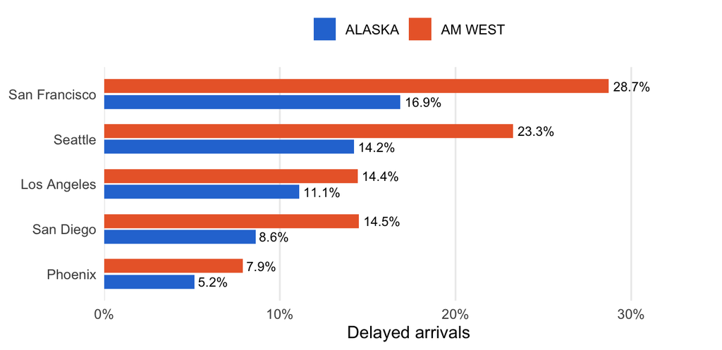

Figure 2: Percentage of arrivals delayed, by city. ALASKA is lower in all five.

```r
flights |>
  mutate(city = fct_reorder(city, delay_rate)) |>
  ggplot(aes(x = delay_rate, y = city, fill = airline)) +
  geom_col(position = position_dodge(width = 0.7), width = 0.62) +
  geom_text(aes(label = percent(delay_rate, 0.1)),
            position = position_dodge(width = 0.7), hjust = -0.12, size = 3.2) +
  scale_fill_manual(values = c(ALASKA = col_alaska, `AM WEST` = col_amwest), name = NULL) +
  scale_x_continuous(labels = percent_format(), limits = c(0, 0.34),
                     expand = expansion(mult = c(0, 0.02))) +
  labs(x = "Delayed arrivals", y = NULL) +
  theme_report +
  theme(legend.position = "top", panel.grid.major.y = element_blank())
```

**City by city, the answer reverses.** ALASKA has a lower delay rate in **every one of the five cities**. The gap ranges from 2.7% in Phoenix to 11.9% in San Francisco. Both airlines struggle in the same places: San Francisco and Seattle are the worst for both, and Phoenix is the best for both.

# 6 The Discrepancy, and Why It Happens

## 6.1 Describing it

Alaska is better in Los Angeles, Phoenix, San Diego, San Francisco and Seattle, yet worse overall. Nothing is wrong with the arithmetic: both statements are true of the same data. This reversal is known as **Simpson’s paradox**.

## 6.2 Explaining it

The overall rate is not a plain average of the five cities. It is an average **weighted by how many flights each airline runs in each city**, and the two airlines fly very different routes.

```r
share <- flights |>
  group_by(airline) |>
  mutate(share_of_flights = total / sum(total)) |>
  ungroup()

share |>
  select(airline, city, total, share_of_flights) |>
  pivot_wider(names_from = airline, values_from = c(total, share_of_flights)) |>
  mutate(across(starts_with("share"), ~ percent(.x, 0.1)))
```

| city | total_ALASKA | total_AM WEST | share_of_flights_ALASKA | share_of_flights_AM WEST |
| --- | --- | --- | --- | --- |
| Los Angeles | 559 | 811 | 14.8% | 11.2% |
| Phoenix | 233 | 5255 | 6.2% | 72.7% |
| San Diego | 232 | 448 | 6.1% | 6.2% |
| San Francisco | 605 | 449 | 16.0% | 6.2% |
| Seattle | 2146 | 262 | 56.8% | 3.6% |

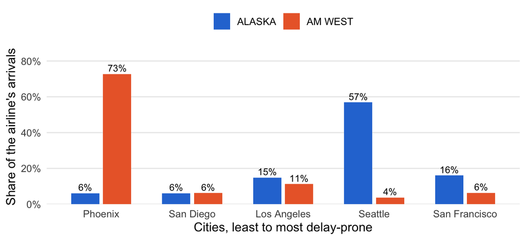

Figure 3: Where each airline flies, as a share of its own arrivals. The cities are ordered by how delay-prone they are overall.

```r
city_order <- flights |>
  group_by(city) |>
  summarise(rate = sum(delayed) / sum(total)) |>
  arrange(rate) |>
  pull(city)

share |>
  mutate(city = factor(city, levels = city_order)) |>
  ggplot(aes(x = city, y = share_of_flights, fill = airline)) +
  geom_col(position = position_dodge(width = 0.7), width = 0.62) +
  geom_text(aes(label = percent(share_of_flights, 1)),
            position = position_dodge(width = 0.7), vjust = -0.4, size = 3.2) +
  scale_fill_manual(values = c(ALASKA = col_alaska, `AM WEST` = col_amwest), name = NULL) +
  scale_y_continuous(labels = percent_format(), limits = c(0, 0.85),
                     expand = expansion(mult = c(0, 0.02))) +
  labs(x = "Cities, least to most delay-prone", y = "Share of the airline's arrivals") +
  theme_report +
  theme(legend.position = "top", panel.grid.major.x = element_blank())
```

This is the whole explanation:

- **AM WEST concentrates on Phoenix**, its hub, which takes 72.7% of its arrivals. Phoenix is the easiest airport in this data, with a 7.8% delay rate across both airlines.
- **ALASKA concentrates on Seattle**, its hub, which takes 56.8% of its arrivals, plus another 16.0% in San Francisco. Those are two of the three most delay-prone cities here; Seattle alone runs at 15.2%.

So AM WEST’s overall figure is dominated by its easiest airport, while ALASKA’s is dominated by its hardest ones. AM WEST looks better overall not because it handles any city better, but because it flies where delays are rare.

## 6.3 Removing the route effect

A fair comparison asks what AM WEST’s overall rate would be if it flew the same mix of cities as ALASKA. That is a weighted average of AM WEST’s own city rates, using ALASKA’s flight counts as the weights.

```r
weights <- flights |> filter(airline == "ALASKA") |> select(city, alaska_flights = total)

standardised <- flights |>
  filter(airline == "AM WEST") |>
  left_join(weights, by = "city") |>
  summarise(rate = sum(delay_rate * alaska_flights) / sum(alaska_flights)) |>
  pull(rate)

tibble(
  comparison = c("ALASKA, actual",
                 "AM WEST, actual",
                 "AM WEST, if it flew ALASKA's mix of cities"),
  delay_rate = percent(c(rate("ALASKA"), rate("AM WEST"), standardised), 0.1)
)
```

| comparison | delay_rate |
| --- | --- |
| ALASKA, actual | 13.3% |
| AM WEST, actual | 10.9% |
| AM WEST, if it flew ALASKA’s mix of cities | 21.4% |

Once both airlines are put on the same routes, AM WEST’s delay rate rises from 10.9% to **21.4%**, well above ALASKA’s 13.3%. The city-by-city comparison is the honest one, and the overall figure was measuring where each airline flies rather than how well it flies.

# 7 Conclusions

- **Tidying mattered.** The source table buried the airline name in blank cells and spread the cities across columns. `fill()` and `pivot_longer()` turned it into one row per airline, city and status, after which every comparison was a single `group_by()`.
- **Percentages, not counts.** AM WEST recorded nearly twice as many arrivals as ALASKA, so counts of delays would have been misleading on their own.
- **The two comparisons disagree.** ALASKA is better in all five cities, yet worse overall. The overall rate is weighted by route mix, and AM WEST runs 72.7% of its flights through the least delay-prone airport in the data.
- **ALASKA is the better airline here.** Standardising to a common mix of cities confirms it: AM WEST would run at 21.4% on ALASKA’s routes, against ALASKA’s 13.3%.

The practical lesson is that an aggregate can reverse the truth of every group inside it. Whenever groups are pooled, it is worth asking what the pooling is weighted by.